# Sesion 28 - Uso de Modelos Lineales Generalizados

Juan Carlos Martinez-Ovando

Departamento Academico de Actuaria

Primavera 2019

# 1 Preliminar

- En esta sesion estudiaremos el uso de `modelos de regresion` (en particular, modelos de `regresion generalizada`) para la prevision de riesgos.
- Las ilustraciones de esta sesion hacen uso de la libreria `R2OpenBUGS`.

```
if(!require("R2OpenBUGS")){install.packages("R2OpenBUGS")}
suppressMessages(library("R2OpenBUGS"))
```

# 2 Motivacion

- Hemos estudiado que para mitigar la incertidumbre sobre el `monto agregado de siniestros`, $S$, de un portafolio, es conveniente estudiar la incertidumbre acerca del `monto individual de siniestros`, $X_j$, bajo la representacion
  $$S=\sum_j X_j.$$
- La incertidumbre acerca de $X_j$ es cuantificada por el modelo de probabilidad
  $$X_j \sim F_{X}(x_j|\theta),$$
  para cierta funci'on de distribuci'on $F()$ y parametro $\theta$.

> Este modelo es aplicado a todos los $X_j$s por igual bajo el supuesto `iid`.

## 2.1 Segmentacion

- Hemos visto tambien que cuando se conocen `variables intrinsecas` adicionales, $Z_j$, las cuales identifican/asocian circunstancias particulares de riesgo para cada $X_j$, circunstancias enunciadas entre las siguientes alternativas excluyentes
  $$\mathcal{Z}=\{1,2,\ldots,K\}$$
  , entonces la incertidumbre acerca de $X_j$ puede definirse condicionamente a $Z_j=k$, como
  $$X_j|Z_j = k \sim F_{k}(x_j|\theta_k),$$
  para algun $k\in \mathcal{Z}$.

> Es decir, definimos $K$, $\left(F_k(|\theta_k)\right)_{k=1}^K$ modelos para las $X_j$ y, dependiendo del valor $Z_j$, se aplica el modelo correspondiente a cada $X_j$.

> Esta es una forma de diversificar el riesgo dentro de un portafolio.

> Es tambien una forma de introducir dependencia adicional para diversificar el riesgo.

## 2.2 Diversificacion

Con el proposito de *extender* la nocion de `diversificacion` anteriores, en ocasiones es conveniente definir el conjunto de `variables intrinsecas` como una coleccion de $p$ variables numericas,
$$Z_j = (Z_{j1},\ldots,Z_{jp}),$$
de manera que, la dependencia de $X_j$ en terminos de las $(z_{j1},\ldots,z_{jp})$ se define en terminos de su `valor esperado`, i.e.,
$$X_j|Z_j = (z_{j1},\ldots,z_{jp}) \sim F(x_j|z_{j1},\ldots,z_{jp}),$$
tal que
$$\mathbb{E}(X_j|z_{j1},\ldots,z_{jp})=\alpha_0 + \alpha_1z_{j1} + \ldots + \alpha_p z_{jp}.$$

> Esta es la `forma general` de expresar el modelo de regresion tradicional
> $$x_j = \alpha_0 + \alpha_1z_{j1} + \ldots + \alpha_p z_{jp} + \varepsilon_j.$$

## 2.3 Comentarios

- El `modelo de regresion` presupone que $X_j$ toma valores en la recta real $\mathbb{R}$.
- En el contexto actuarial, como en muchos otros contextos, la variable $X_j$ tiene soporte acotado. En nuestro caso particular, tipicamente
  $$X_j \in \mathcal{X}=\mathbb{R}_+=(0,\infty),$$
  cuando $X_j$ representa el `monto individual de reclamos`, o
  $$X_j \in \mathcal{X}=\{0,1\},$$
  cuando $X_j$ representa la `ocurrencia de siniestro`, o
  $$X_j \in \mathcal{X}=\mathbb{N}=\{0,1,2,\ldots\},$$
  cuando $X_j$ representa la `frecuencia de siniestros (conteos)` de un portafolio de seguros.

La circunstancia anterior require `generalizar el modelo de regresion`, dando pie a los `modelos de regresion generalizados`.

# 3 Modelos de regresion generalizados

## 3.1 Regresion Poisson

En este caso, por notacion, remplazamos $X_j$ por $N_j$, como lo hicimos en las notas previas del curso.

De esta forma, la especificacion de la distribucion para $N_j$, sin segmentacion, es de la forma
$$N_j|Z_j=z_j \sim \text{Po}(n_j|\lambda_j),$$
tal que
$$\begin{eqnarray}
\mathbb{E}_{\text{Po}}(N_j|z_j) & = & \lambda_j \\
& = & \lambda(z_j) \\
& = & \exp\{\alpha_0+\alpha_1 z_{j1}+\ldots+\alpha_p z_{jp}\}.
\end{eqnarray}$$
Esta especificacion define la clase de `modelos de regresion Poisson`.

### 3.1.1 Ilustracion

Consideremos el siguiente ejemplo de `conteos` de billetes falsificados en Mexico:

```r
library("R2OpenBUGS")
datos <- read.csv("act11302_sesion_28_datos2.csv", header=TRUE)
datos <- as.data.frame(datos)

attach(datos)
time <- Year
y <- F20
n <- length(y)

detach(datos)
data <- list("n"=n,"y"=y,"time"=time)
head(data)
```

```
## $n
## [1] 12
##
## $y
##  [1] 14.8 13.1 18.1  9.4  1.5  1.0  0.7  0.6  1.0  3.2  2.7  1.3
##
## $time
##  [1] 2000 2001 2002 2003 2004 2005 2006 2007 2008 2009 2010 2011
```

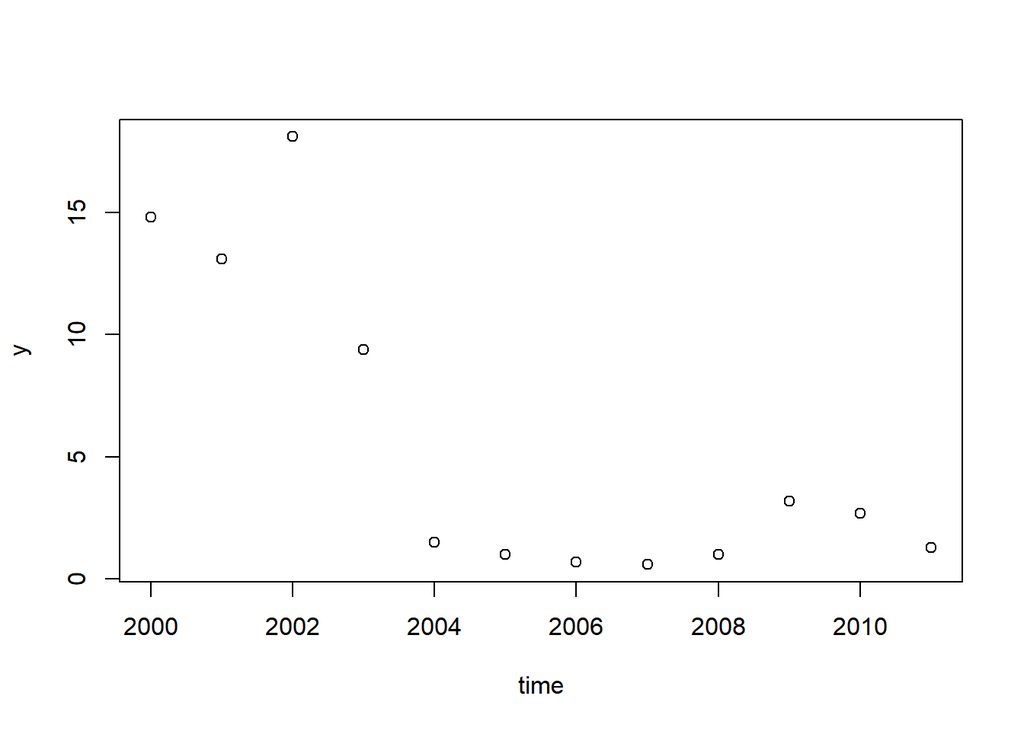

```r
plot(time,y)
```

El indice de observaciones, en este caso, corresponde al tiempo, i.e.
$$j \in \{1,\ldots,12\}.$$
La variable que necesitamos definir en este contexto es la variable `dummy` o `indicadora` de que el tiempo sea posterior al anio `2003`, i.e.
$$Z_j =\mathbb{I}(t_{j-1} \geq 2003).$$

Es decir,
$$Z_j =
\begin{cases}
0 & t_{j-1} < 2003,\\
1 & t_{j-1} \geq 2003.\\
\end{cases}$$

Asi, el modelo queda especificado con
$$\lambda_j = \exp\{\alpha_0 + \alpha_1 z_{j-1}\}.$$

> A diferencia del modelo de regresion tradicional, en el `modelo de regresion poisson` la estimacion de los parametros $\alpha_0$ y $\alpha_1$ se obtienen de forma numerica (no analitica), tanto en el enfoque `frecuentista` como `bayesiano`.

En nuestra ilustracion, empleamos el `enfoque bayesiano`. La estimacion/inferencia se realiza empleando el algoritmo *Gibbs sampler*, para lo cual es necesario definir valores iniciales:

```r
inits <- function(){list(c=sample(1:12,1), b=rep(0,2))}
```

Monitoreamos en este algoritmo los siguientes parametros

```r
parameters<-c("a","b","mu")
```

El algoritmo numerico esta implementado en OpenBUGS, el codigo de especificacion del modelo es especificado en el archivo `act11302_sesion_28_Ex3-R`:

```
model{
  #Likelihood
  for (i in 1:n){
    y[i]~dpois(mu[i])
    log(mu[i])<-b[1]+b[2]*step(time[i]-a)
  }
  #Priors
  a <- c+1999
  c ~ dcat(p[])
  for (j in 1:12){p[j]<-1/12}
  for (j in 1:2){b[j]~dnorm(0,0.001)}
}
```

Asi, el modelo se implementa con la siguiente instruccion:

```r
library("R2OpenBUGS")
poissreg.sim <- bugs(data, inits, parameters,
                     model.file="act11302_sesion_28_Ex3.R",
                     n.iter=20000,
                     n.chains=1,
                     n.burnin=5000)
```

El resumen del proceso numerico de estimacion se obtiene de la siguiente forma:

```r
poissreg.out <- poissreg.sim$summary[,c(1,3,7)]
print(poissreg.out)
```

```
##                 mean        2.5%       97.5%
## a        2003.999400 2004.000000 2004.000000
## b[1]        2.608588    2.319975    2.863000
## b[2]       -2.407519   -3.038000   -1.791000
## mu[1]      13.705488   10.170000   17.520000
## mu[2]      13.705488   10.170000   17.520000
## mu[3]      13.705488   10.170000   17.520000
## mu[4]      13.696038   10.170000   17.510000
## mu[5]       1.275061    0.686300    2.123025
## mu[6]       1.275061    0.686300    2.123025
## mu[7]       1.275061    0.686300    2.123025
## mu[8]       1.275061    0.686300    2.123025
## mu[9]       1.275061    0.686300    2.123025
## mu[10]      1.275061    0.686300    2.123025
## mu[11]      1.275061    0.686300    2.123025
## mu[12]      1.275061    0.686300    2.123025
## deviance   43.554413   41.680000   48.660250
```

La devianza (a.k.a. `deviance`) es una medida de ajuste del modelo, y se define *grosso modo* como
$$-2\log lik(\hat{\theta}|\text{datos}).$$

#### 3.1.1.1 Inferencia para $a$

```r
a.sim <- poissreg.sim$sims.list$a
prop.table(table(a.sim))
```

```
## a.sim
##   2003   2004
## 0.0006 0.9994
```

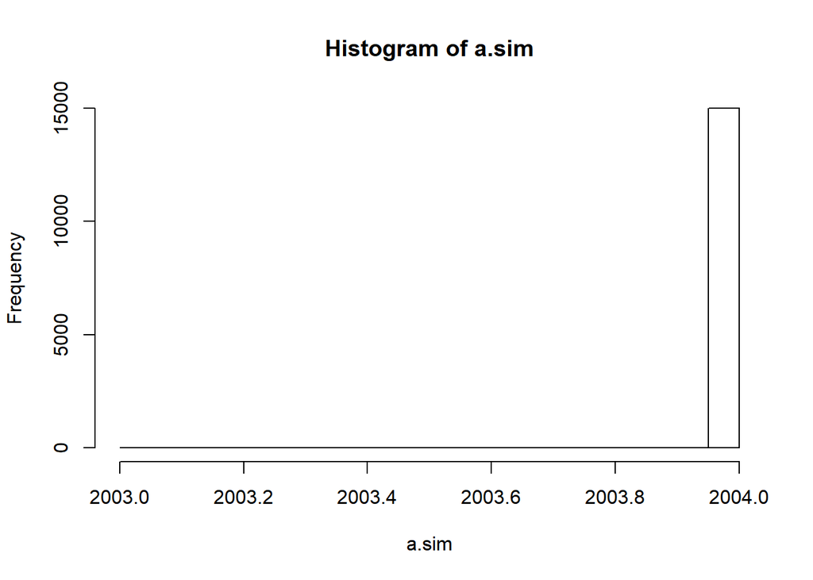

```r
hist(a.sim)
```

Las tasas de intensidad del modelo se recuperan como:

```r
mu.sim <- poissreg.sim$summary[4:15,c(1,3,7)]
print(mu.sim)
```

```
##             mean    2.5%     97.5%
## mu[1]  13.705488 10.1700 17.520000
## mu[2]  13.705488 10.1700 17.520000
## mu[3]  13.705488 10.1700 17.520000
## mu[4]  13.696038 10.1700 17.510000
## mu[5]   1.275061  0.6863  2.123025
## mu[6]   1.275061  0.6863  2.123025
## mu[7]   1.275061  0.6863  2.123025
## mu[8]   1.275061  0.6863  2.123025
## mu[9]   1.275061  0.6863  2.123025
## mu[10]  1.275061  0.6863  2.123025
## mu[11]  1.275061  0.6863  2.123025
## mu[12]  1.275061  0.6863  2.123025
```

```r
dim(mu.sim)
```

```
## [1] 12  3
```

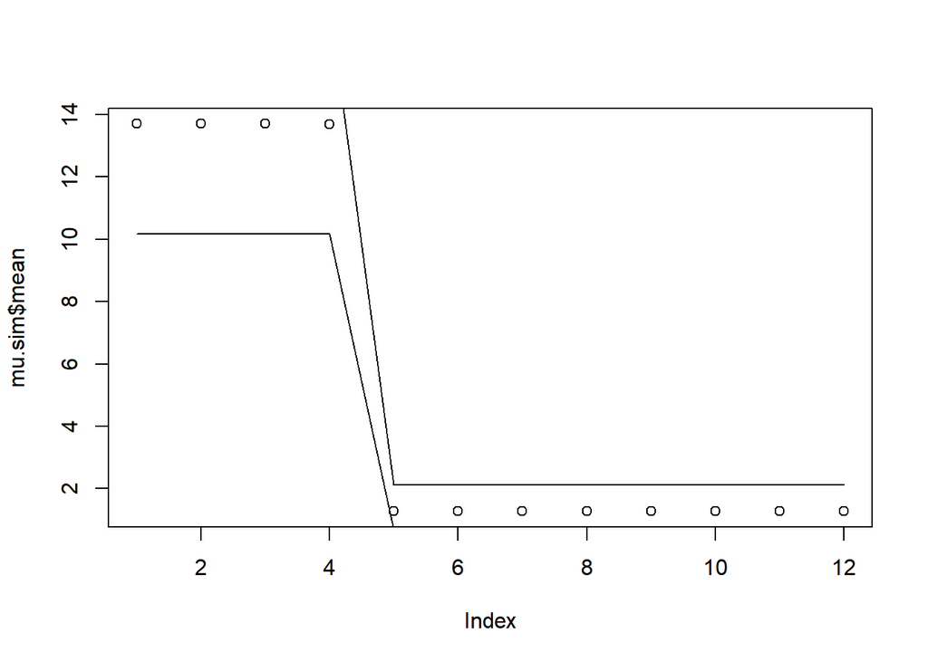

```r
mu.sim <-as.matrix(mu.sim)
mu.sim <-as.data.frame(mu.sim)
colnames(mu.sim) <- c("mean", "liminf","limsup")
plot(mu.sim$mean)
lines(mu.sim$liminf)
lines(mu.sim$limsup)
```

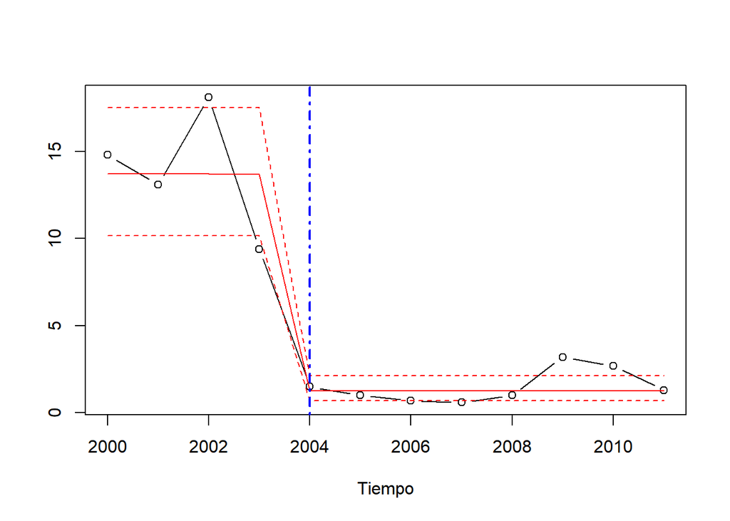

```r
ymin <- min(mu.sim, y)
ymax <- max(mu.sim, y)
plot(time, y,
     ylim=c(ymin,ymax),
     type="b",
     xlab="Tiempo",ylab="")
lines(time,mu.sim[,1], col=2)
lines(time,mu.sim[,2], lty=2,col=2)
lines(time,mu.sim[,3], lty=2,col=2)
abline(v=poissreg.out[1,1],col=4,lwd=2,lty=4)
```

## 3.2 Comentarios

- El modelo de regresion Poisson permite caracterizar modelos heterogenos de conteos asociados con covariables numericas de segmentacion.
- La especificacion anterior es lo suficientemente flexible para ser modificada e introducir varias especificaciones de covariables de segmentacion.
- El modelo de regresion Poisson es un caso particular de los `modelos lineales generalizados` (o `GLM` por sus siglas en ingles).

# 4 Formalizacion

Los `GLM` estan especificados de manera que la variable de respuesta, $X_j$, tiene una distribucion asociada con la `familia exponencial de distribuciones`, i.e.
$$f_{X}(x) = (2\pi /\tau) \exp\{-(\tau/2)(x-\mu)^2\},$$
donde
$$\begin{eqnarray}
\phi & = & \tau ,\\
b(x,\phi) & = & (2\pi/\phi)^{-1/2}\exp\{(\phi/2)x^2\},\\
\theta & = & \mu,\\
a(\theta) & = & \theta^2/2.
\end{eqnarray}$$

Asi, entre esta clase de modelo, encontramos:

- Modelo de regresion Poisson
- Modelo de regresion binaria (`logit`)
- Modelo de regresion gamma

# 5 Ejercicio

1. Escriban el modelo de regresion Poisson que estudiamos en la forma de `GLM`.

# 6 Lecturas adicionales

- Makov (2001) *Principal applications of Bayesian methods in actuarial science: a perspective.* North American Actuarial Journal, 5(4), 53–73.
- Makov et al (1996) *Bayesian methods in actuarial science.* Journal of the Royal Statistical Society. Series D (The Statistician), 45(4), 503–515.